# The benford.analysis R package (draft)

```r
#devtools::install_github("carloscinelli/benford.analysis", build_vignettes = TRUE)
library(benford.analysis)
```

# Census 2009

The census.2009 dataset contains the population of towns and cities of the United States, as of july of 2009.

```r
data(census.2009)
head(census.2009)
```

```
##     state             town pop.2009
## 1 Alabama   Abbeville city     2930
## 2 Alabama  Adamsville city     4782
## 3 Alabama     Addison town      709
## 4 Alabama       Akron town      433
## 5 Alabama   Alabaster city    29861
## 6 Alabama Albertville city    20115
```

We use the benford function in the appropriate column to validate the data against Benford’s law:

```r
c2009 <- benford(census.2009$pop.2009)
```

The main plots of the analysis are shown in the next Figure.

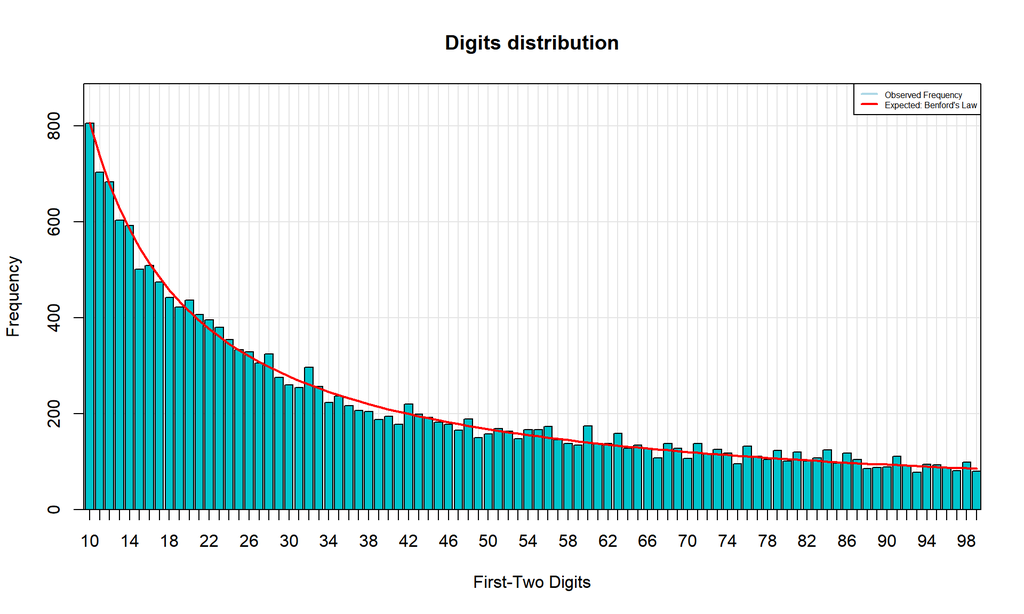

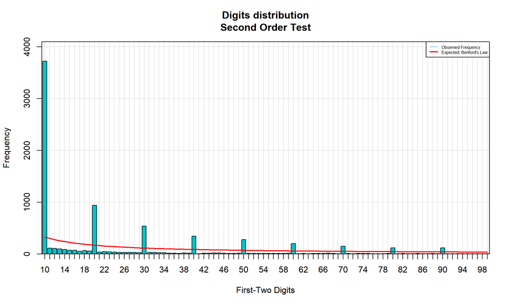

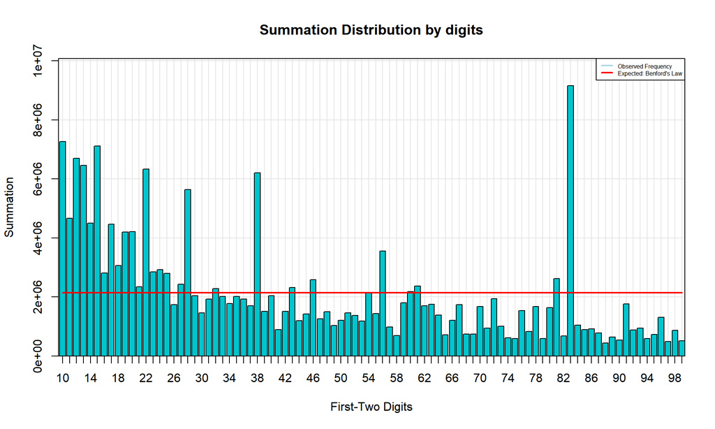

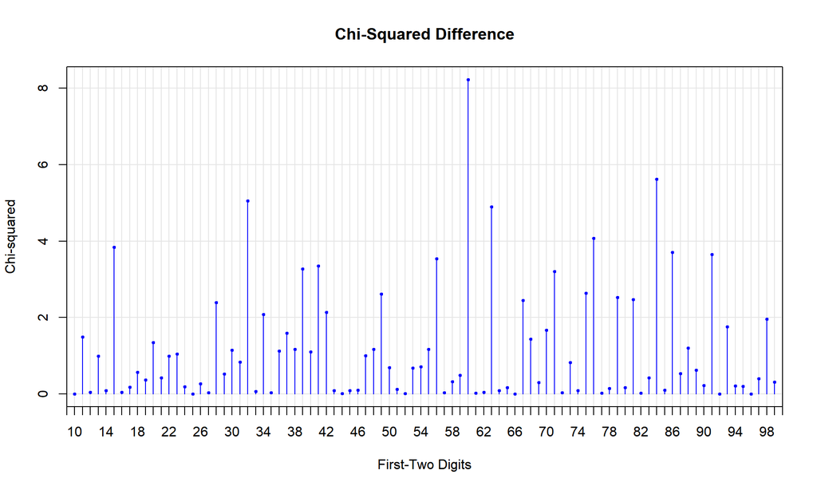

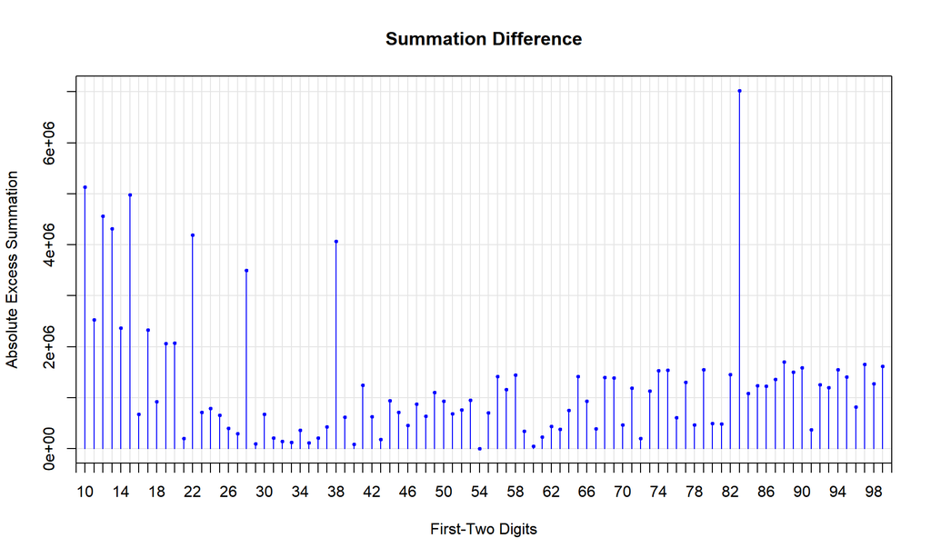

```r
plot(c2009)
```

The original data is in blue and the expected frequency according to Benford’s law is in red. The first-two digits of the 19,509 population numbers are shown in the next first graph. We can see that digits of the census numbers in Figure show a very good fit to Benford’s Law. The heights of the bars are very close to the line of Benford’s Law.

The second-order result for the population data shows a pattern of declining prime spikes and a pattern of declining minor spikes.

The main results of the analysis are as follows:

```r
c2009
```

```
##
## Benford object:
##
## Data: census.2009$pop.2009
## Number of observations used = 19509
## Number of obs. for second order = 7950
## First digits analysed = 2
##
## Mantissa:
##
##    Statistic  Value
##         Mean  0.503
##          Var  0.084
##  Ex.Kurtosis -1.207
##     Skewness -0.013
##
##
## The 5 largest deviations:
##
##   digits absolute.diff
## 1     15         45.81
## 2     32         36.28
## 3     60         33.95
## 4     11         33.22
## 5     28         26.68
##
## Stats:
##
##  Pearson's Chi-squared test
##
## data:  census.2009$pop.2009
## X-squared = 107.16, df = 89, p-value = 0.09222
##
##
##  Mantissa Arc Test
##
## data:  census.2009$pop.2009
## L2 = 4.198e-05, df = 2, p-value = 0.4409
##
##
##  Kolmogorov-Smirnov test
##
## data:  census.2009$pop.2009
## D = 0.0094454, critical value = 0.0097369, alpha = 0.0500000
##
## Mean Absolute Deviation (MAD): 0.0006134141
## MAD Conformity - Nigrini (2012): Close conformity
## Distortion Factor: 0.7404623
##
## Remember: Real data will never conform perfectly to Benford's Law. You should not focus on p-values!
```

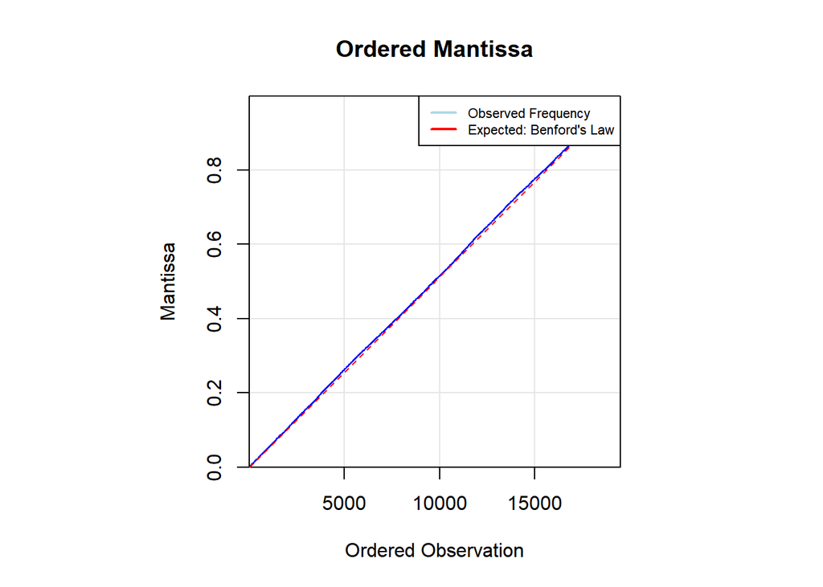

```r
plot(c2009, select = "mantissa")
```

By first-two digits test and the mantissa test the town and city census data showed a close conformity to Benford’s Law.

# Census 2000 and 2010

The census.2000_2010 dataset contains population data of the United States - 2000 and 2010.

```r
data(census.2000_2010)
head(census.2000_2010)
```

```
##   fips           name    area pop.2000 pop.2010
## 1 1001 Autauga County  594.44    43671    54571
## 2 1003 Baldwin County 1589.78   140415   182265
## 3 1005 Barbour County  884.88    29038    27457
## 4 1007    Bibb County  622.58    20826    22915
## 5 1009  Blount County  644.78    51024    57322
## 6 1011 Bullock County  622.80    11714    10914
```

You use the benford function to obtain the benford analysis:

```r
c2010 <- benford(census.2000_2010$pop.2010)
```

Now, you can see the main plots of the analysis by running:

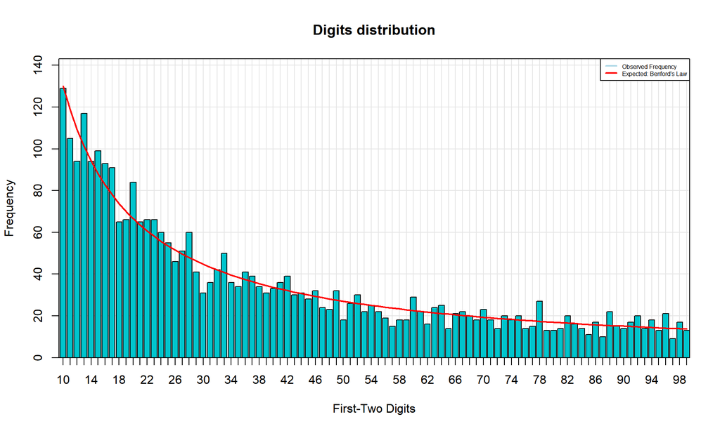

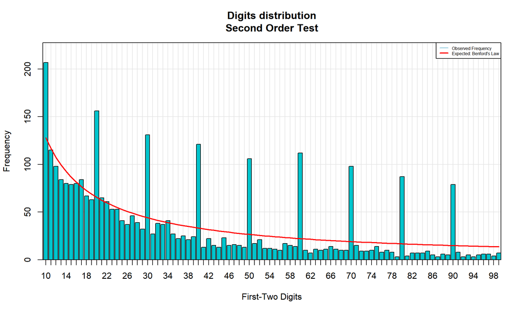

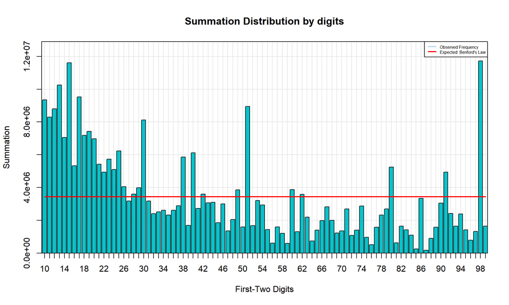

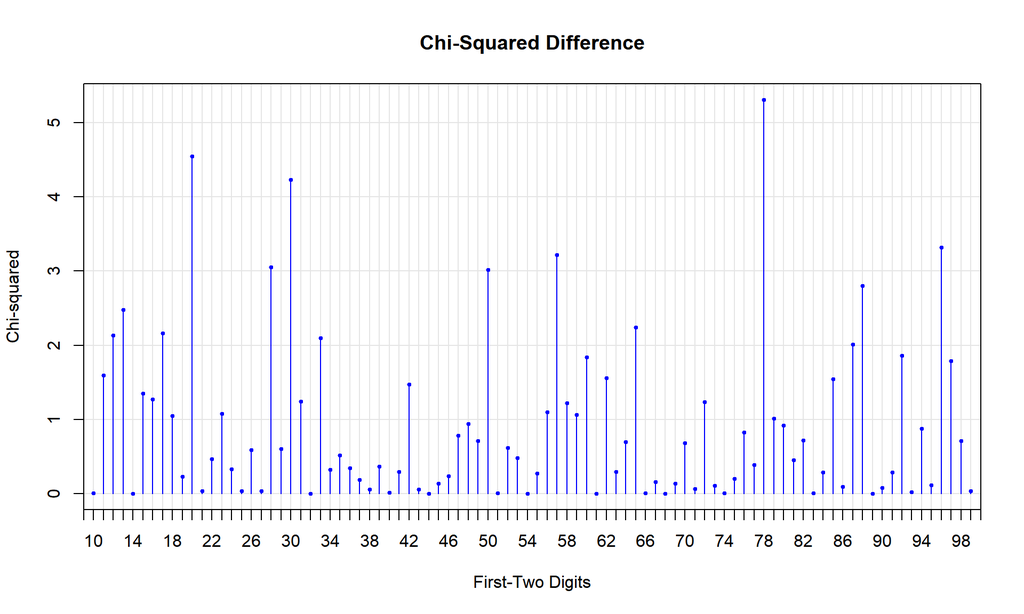

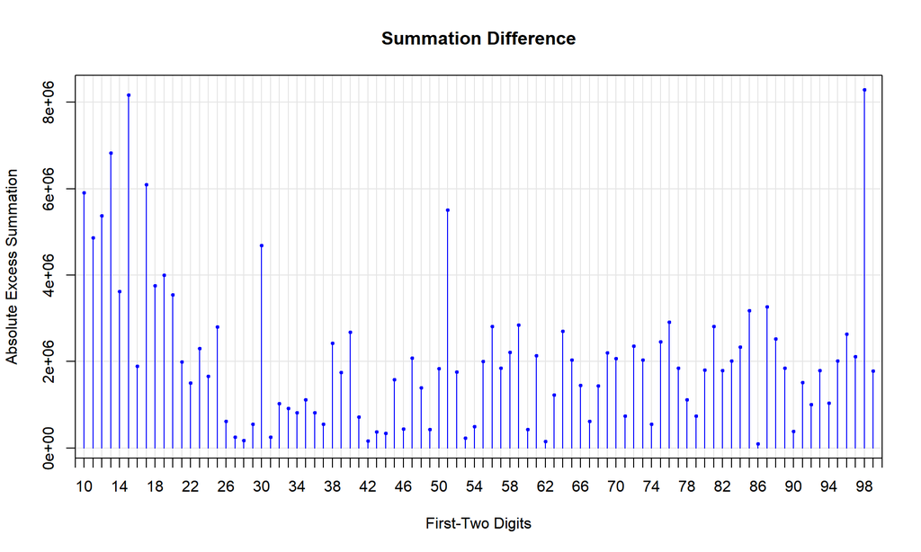

```r
plot(c2010)
```

For you to see the main results just run the benford object `c2010`.

```r
c2010
```

```
##
## Benford object:
##
## Data: census.2000_2010$pop.2010
## Number of observations used = 3143
## Number of obs. for second order = 3090
## First digits analysed = 2
##
## Mantissa:
##
##    Statistic  Value
##         Mean  0.496
##          Var  0.083
##  Ex.Kurtosis -1.191
##     Skewness  0.052
##
##
## The 5 largest deviations:
##
##   digits absolute.diff
## 1     20         17.40
## 2     13         15.84
## 3     12         15.26
## 4     11         13.77
## 5     30         13.76
##
## Stats:
##
##  Pearson's Chi-squared test
##
## data:  census.2000_2010$pop.2010
## X-squared = 82.809, df = 89, p-value = 0.6646
##
##
##  Mantissa Arc Test
##
## data:  census.2000_2010$pop.2010
## L2 = 0.00076042, df = 2, p-value = 0.09163
##
##
##  Kolmogorov-Smirnov test
##
## data:  census.2000_2010$pop.2010
## D = 0.016762, critical value = 0.024259, alpha = 0.050000
##
## Mean Absolute Deviation (MAD): 0.001428017
## MAD Conformity - Nigrini (2012): Acceptable conformity
## Distortion Factor: -0.7805108
##
## Remember: Real data will never conform perfectly to Benford's Law. You should not focus on p-values!
```

According to the plot below, note that the blue line is very close to expected (red line) if the mantissa has uniform distribution.

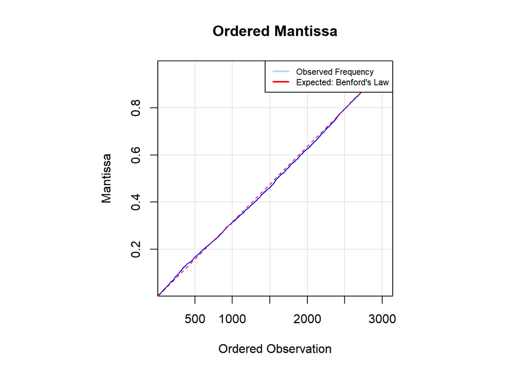

```r
plot(c2010, select = "mantissa")
```

# Lakes Perimeter

The `lakes.perimeter` is a dataset containing the perimeter of the lakes arround the water from the global lakes and wetlands database (GLWD). The data table has the data for 248,607 water bodies. This data was analyzed in Nigrini and Miller (2007) and Nigrini (2012).

```r
data(lakes.perimeter)
head(lakes.perimeter)
```

```
##   perimeter.km
## 1          1.0
## 2          1.0
## 3          1.1
## 4          1.1
## 5          1.1
## 6          1.1
```

Data summary of the lake perimeters:

```r
summary(lakes.perimeter$perimeter.km, horizontal = T)
```

```
##     Min.  1st Qu.   Median     Mean  3rd Qu.     Max.
##     1.00     4.00     5.60    14.64     9.30 36641.20
```

The lake perimeters ranged from 1 km to 36,641 km. The perimeters are positively skewed and with one-half of the values ranging from 4 to 9.3.

The benford function is used to obtain the benford analysis:

```r
lk <- benford(lakes.perimeter$perimeter.km)
```

The first-two digits of the lake perimeters are shown in the next Figure.

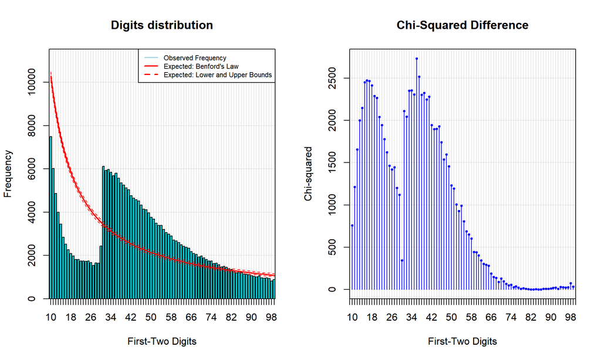

```r
plot(lk, select = c("digits", "chi squared"), err.bounds = T)
```

```r
lk$distortion.factor
```

```
## [1] -43.31794
```

The digit patterns of the lake perimeter data do not conform to Benford’s Law.

```r
MAD(lk)
```

```
## [1] 0.006012766
```

```r
lk$MAD.conformity
```

```
## [1] "Nonconformity"
```

We can conclude that mantissa is not evenly distributed:

```r
marc(lk)
```

```
##
##  Mantissa Arc Test
##
## data:  lakes.perimeter$perimeter.km
## L2 = 0.13996, df = 2, p-value < 2.2e-16
```

Note the distance between the blue line and the red line:

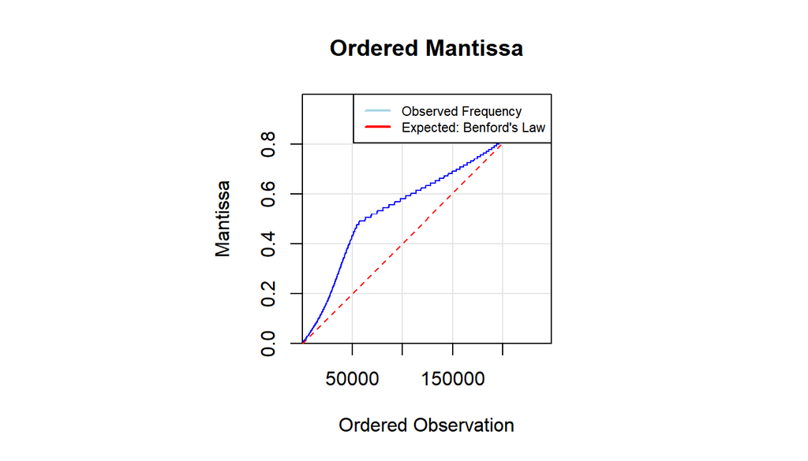

```r
plot(lk, select = "mantissa")
```

Observations with the largest discrepancies:

```r
suspects <- getSuspects(lk, lakes.perimeter, by = "squared.diff")
suspects
```

```
##        perimeter.km
##     1:          3.6
##     2:          3.6
##     3:          3.6
##     4:          3.6
##     5:          3.6
##    ---
## 11369:        379.2
## 11370:       3681.7
## 11371:       3713.2
## 11372:       3751.5
## 11373:      36641.2
```

# Taxable incomes

Here we will give an example using data of Taxable Incomes of the 1978 Individual Tax Model File (ITMF).

```r
data(taxable.incomes.1978)
head(taxable.incomes.1978)
```

```
##   taxIncomes
## 1       5601
## 2       4977
## 3       5959
## 4       6267
## 5       5221
## 6       3094
```

```r
summary(taxable.incomes.1978$taxIncomes)
```

```
##     Min.  1st Qu.   Median     Mean  3rd Qu.     Max.
##        0    13376    27359    90914    74589 21541002
```

The reported amounts ranged from a low of $0 to a maximum of $21,541,002. The average interest amount (excluding the zeros) was $90,914. So, the taxable incomes sample is highly skewed toward high-income taxpayers.

Applying the benford analysis:

```r
ti <- benford(taxable.incomes.1978$taxIncomes)
```

Main plots of the benford analysis:

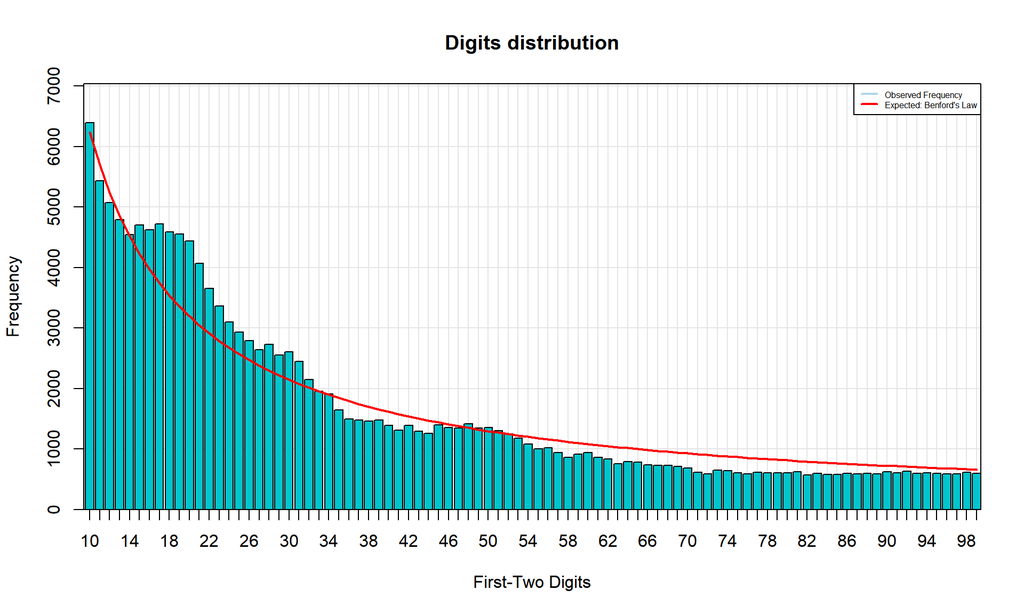

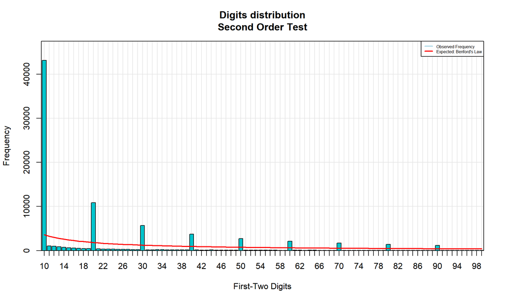

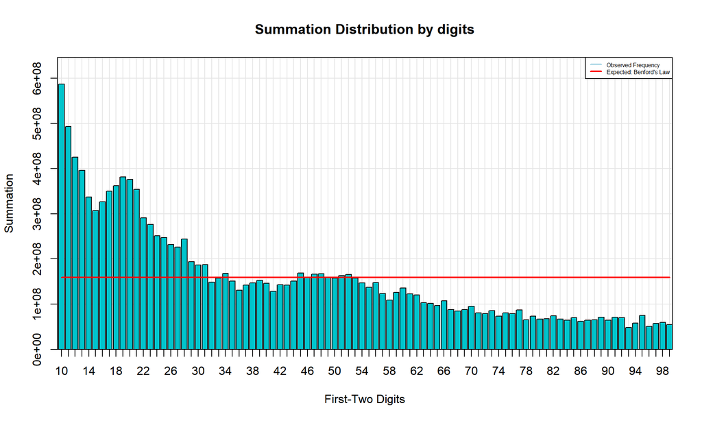

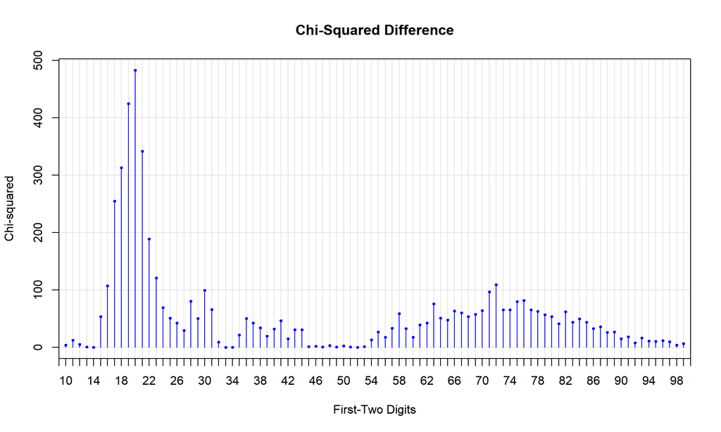

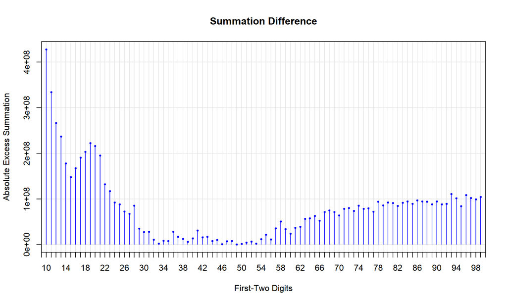

```r
plot(ti)
```

The print of the principal results:

```r
ti
```

```
##
## Benford object:
##
## Data: taxable.incomes.1978$taxIncomes
## Number of observations used = 150760
## Number of obs. for second order = 86467
## First digits analysed = 2
##
## Mantissa:
##
##    Statistic  Value
##         Mean  0.467
##          Var  0.077
##  Ex.Kurtosis -1.047
##     Skewness  0.198
##
##
## The 5 largest deviations:
##
##   digits absolute.diff
## 1     20       1242.50
## 2     19       1194.61
## 3     18       1052.99
## 4     21       1020.14
## 5     17        976.60
##
## Stats:
##
##  Pearson's Chi-squared test
##
## data:  taxable.incomes.1978$taxIncomes
## X-squared = 5109.9, df = 89, p-value < 2.2e-16
##
##
##  Mantissa Arc Test
##
## data:  taxable.incomes.1978$taxIncomes
## L2 = 0.013223, df = 2, p-value < 2.2e-16
##
##
##  Kolmogorov-Smirnov test
##
## data:  taxable.incomes.1978$taxIncomes
## D = 0.071374, critical value = 0.0035026, alpha = 0.0500000
##
## Mean Absolute Deviation (MAD): 0.001684866
## MAD Conformity - Nigrini (2012): Acceptable conformity
## Distortion Factor: -8.130494
##
## Remember: Real data will never conform perfectly to Benford's Law. You should not focus on p-values!
```

Plot to check if mantissa is evenly distributed:

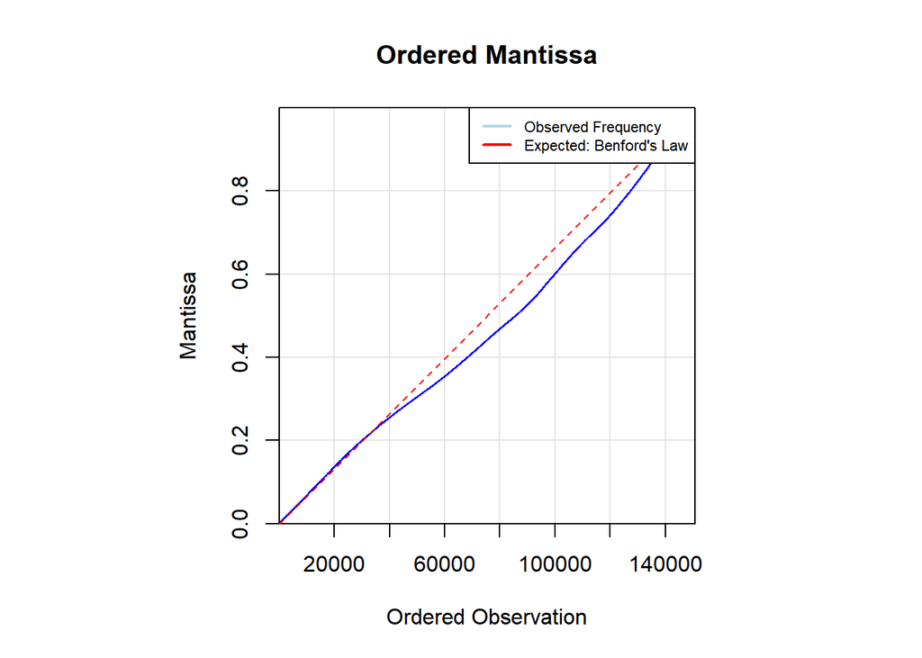

```r
plot(ti, select = "mantissa")
```

# Sino-Forest

The sino.ferest dataset contains Financial Statemens numbers of Sino Forest Corporation’s 2010 Report.

```r
data(sino.forest)
head(sino.forest)
```

```
##     value
## 1 1923536
## 2 1238185
## 3 1252023
## 4  797800
## 5   89712
## 6   63980
```

Applying the benford analysis for first digit:

```r
sf_1d <- benford(sino.forest$value, 1)
```

Plot of the first digits:

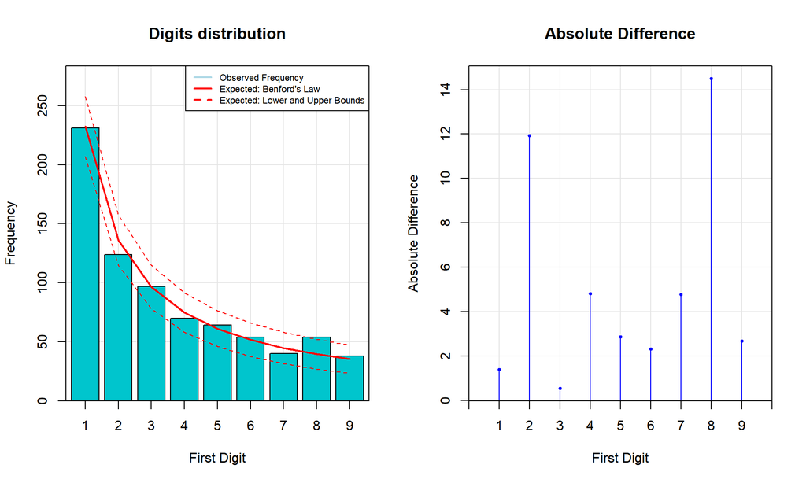

```r
plot(sf_1d, select = c("digits", "abs diff"), err.bounds = T)
```

```r
MAD(sf_1d)
```

```
## [1] 0.006598135
```

```r
sf_1d$MAD.conformity
```

```
## [1] "Acceptable conformity"
```

The first digits in Figure above have an acceptable conformity with their MAD of 0.0065. There are an excess of 8s.

Applying the benford analysis for first two digits:

```r
sf_2d <- benford(sino.forest$value, 2)
```

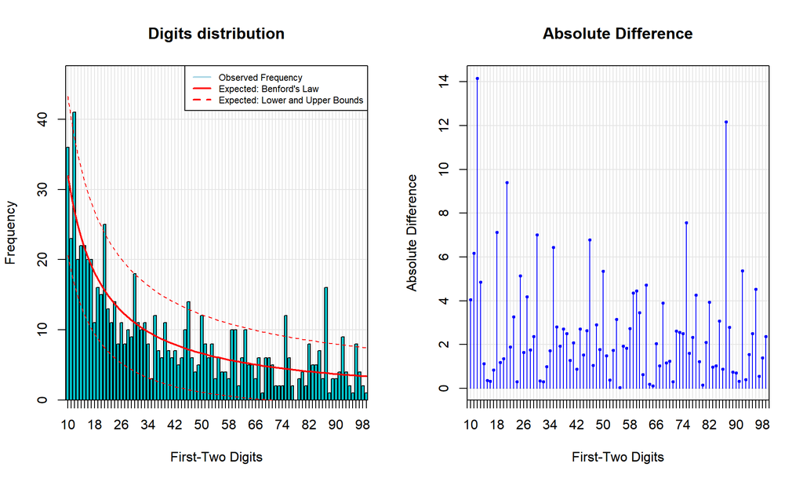

```r
plot(sf_2d, select = c("digits","abs diff"), err.bounds = T)
```

```r
MAD(sf_2d)
```

```
## [1] 0.003463887
```

```r
sf_2d$MAD.conformity
```

```
## [1] "Nonconformity"
```

The first-two digits in above Figure show a marginally nonconformity with a MAD of 0.0034.

The second-order results show the general pattern expected for this test. but the results are not perfect.

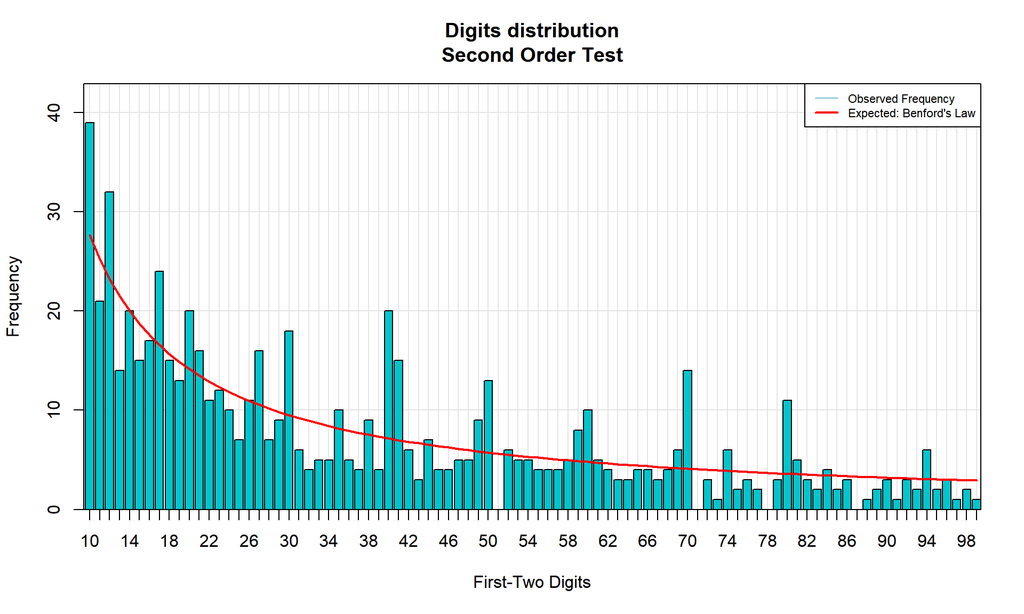

```r
plot(sf_2d, select = "second order")
```

The print of the principal results:

```r
sf_2d
```

```
##
## Benford object:
##
## Data: sino.forest$value
## Number of observations used = 772
## Number of obs. for second order = 668
## First digits analysed = 2
##
## Mantissa:
##
##    Statistic  Value
##         Mean  0.505
##          Var  0.088
##  Ex.Kurtosis -1.255
##     Skewness -0.034
##
##
## The 5 largest deviations:
##
##   digits absolute.diff
## 1     12         14.16
## 2     87         12.17
## 3     21          9.40
## 4     75          7.56
## 5     18          7.13
##
## Stats:
##
##  Pearson's Chi-squared test
##
## data:  sino.forest$value
## X-squared = 166.82, df = 89, p-value = 1.139e-06
##
##
##  Mantissa Arc Test
##
## data:  sino.forest$value
## L2 = 0.0021668, df = 2, p-value = 0.1877
##
##
##  Kolmogorov-Smirnov test
##
## data:  sino.forest$value
## D = 0.027565, critical value = 0.048947, alpha = 0.050000
##
## Mean Absolute Deviation (MAD): 0.003463887
## MAD Conformity - Nigrini (2012): Nonconformity
## Distortion Factor: 2.260385
##
## Remember: Real data will never conform perfectly to Benford's Law. You should not focus on p-values!
```

Plot to check if mantissa is evenly distributed:

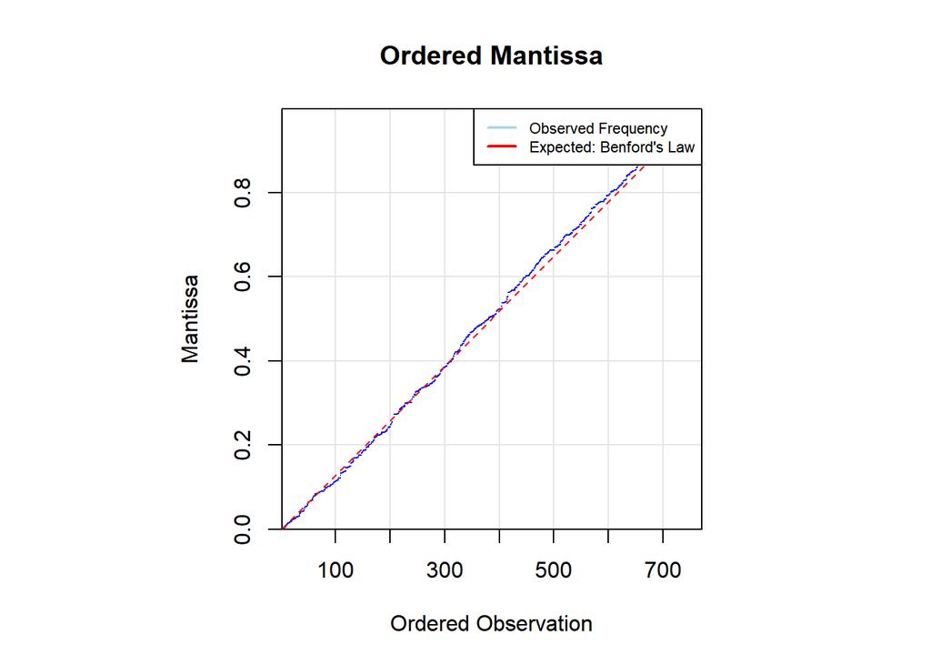

```r
plot(sf_2d, select = "mantissa")
```

# Corporate Payments

```r
data(corporate.payment)
head(corporate.payment)
```

```
##   VendorNum       Date  InvNum Amount
## 1      2001 2010-01-02 0496J10  36.08
## 2      2001 2010-01-02 1726J10  77.80
## 3      2001 2010-01-02 2104J10  34.97
## 4      2001 2010-01-02 2445J10  59.00
## 5      2001 2010-01-02 3281J10  59.56
## 6      2001 2010-01-02 3822J10  50.38
```

```r
cp <- benford(corporate.payment$Amount, 2, sign="both")
```

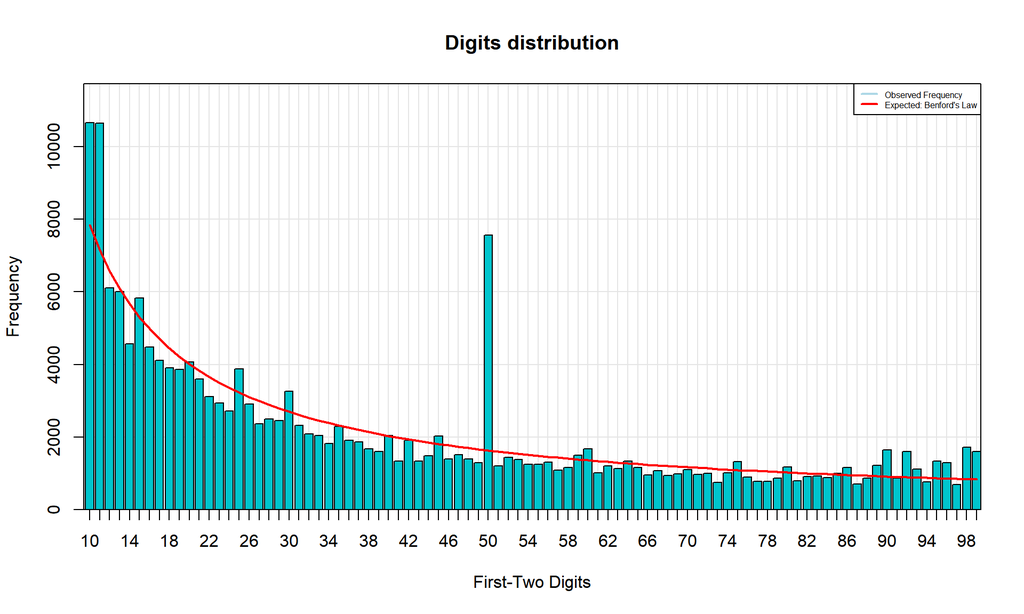

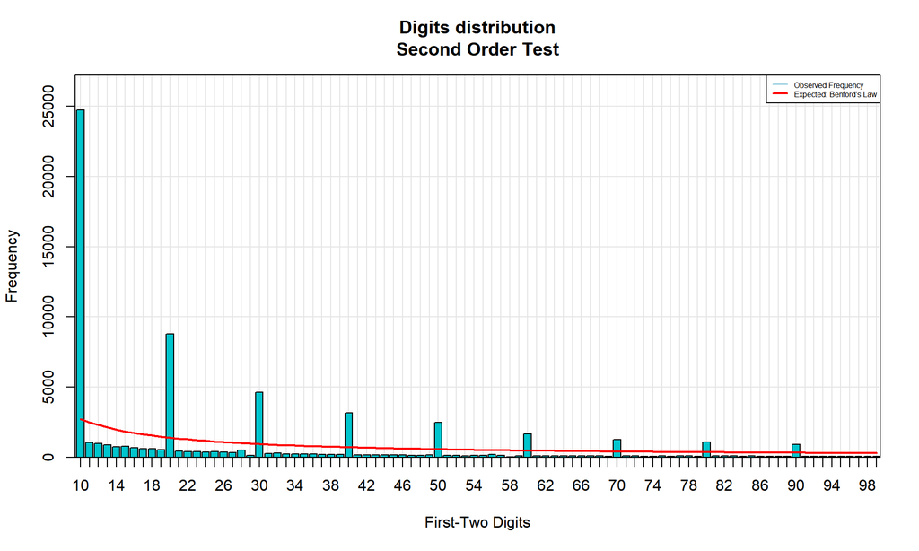

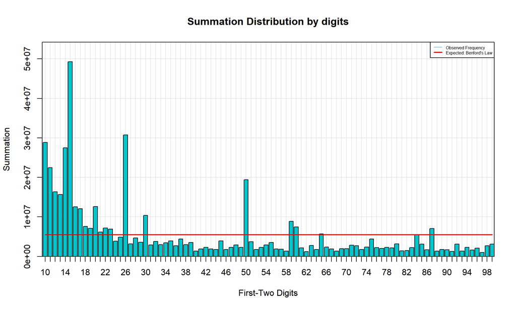

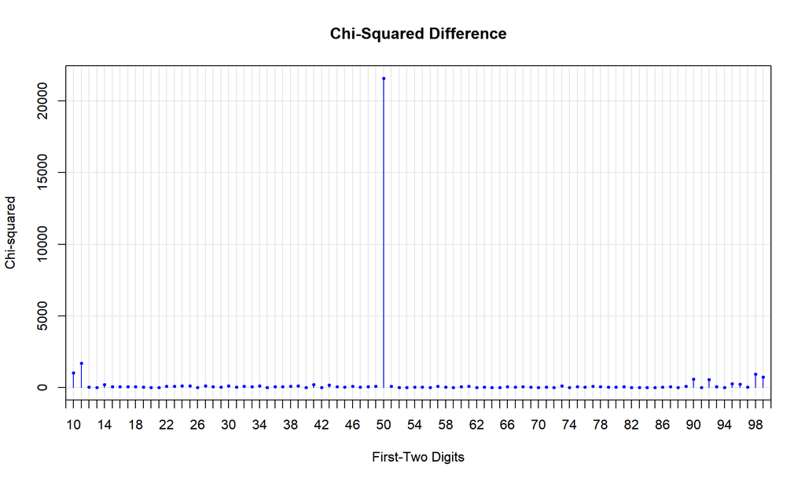

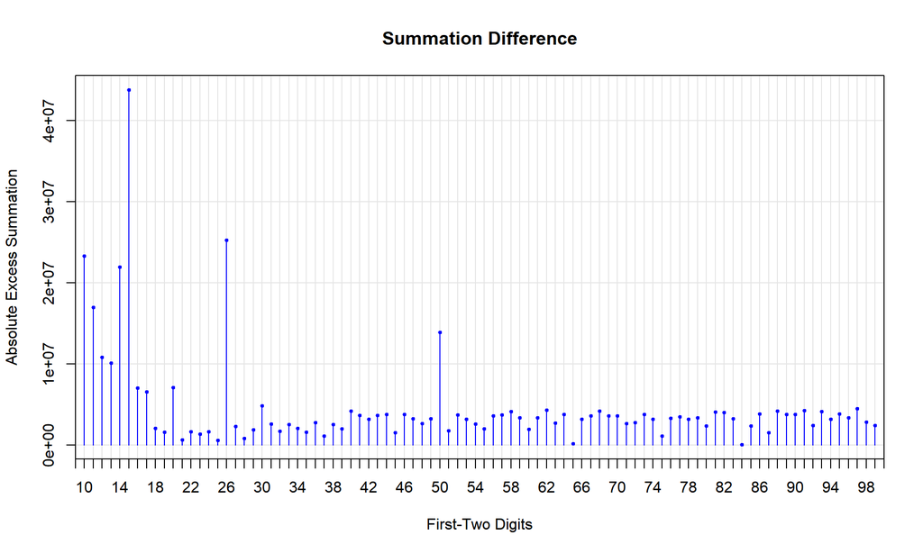

```r
plot(cp)
```

```r
cp
```

```
##
## Benford object:
##
## Data: corporate.payment$Amount
## Number of observations used = 189347
## Number of obs. for second order = 65853
## First digits analysed = 2
##
## Mantissa:
##
##    Statistic    Value
##         Mean  0.49573
##          Var  0.09191
##  Ex.Kurtosis -1.25840
##     Skewness -0.00035
##
##
## The 5 largest deviations:
##
##   digits absolute.diff
## 1     50       5929.58
## 2     11       3496.85
## 3     10       2835.42
## 4     14       1110.45
## 5     98        885.15
##
## Stats:
##
##  Pearson's Chi-squared test
##
## data:  corporate.payment$Amount
## X-squared = 31890, df = 89, p-value < 2.2e-16
##
##
##  Mantissa Arc Test
##
## data:  corporate.payment$Amount
## L2 = 0.0041627, df = 2, p-value < 2.2e-16
##
##
##  Kolmogorov-Smirnov test
##
## data:  corporate.payment$Amount
## D = 0.033443, critical value = 0.0031254, alpha = 0.0500000
##
## Mean Absolute Deviation (MAD): 0.002336108
## MAD Conformity - Nigrini (2012): Nonconformity
## Distortion Factor: -1.017475
##
## Remember: Real data will never conform perfectly to Benford's Law. You should not focus on p-values!
```

Plot to check if mantissa is evenly distributed:

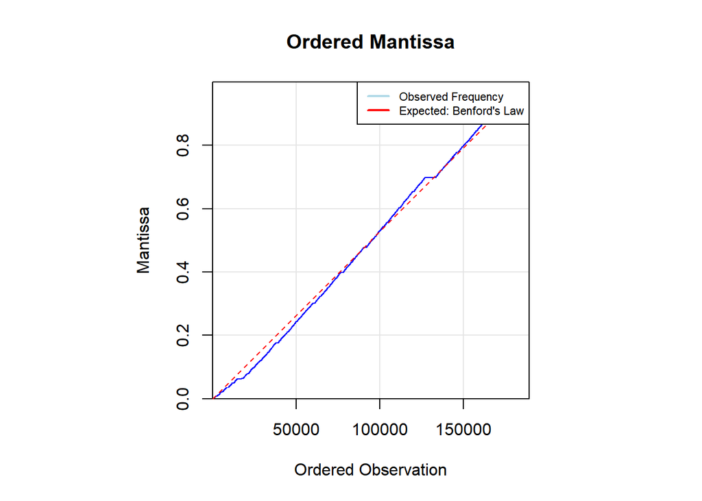

```r
plot(cp, select = "mantissa")
```

Observations with the largest discrepancies:

```r
suspects <- getSuspects(cp, corporate.payment)
suspects
```

```
##        VendorNum       Date       InvNum  Amount
##     1:      2001 2010-01-02      3822J10   50.38
##     2:      2001 2010-01-07     100107-2 1166.29
##     3:      2001 2010-01-08  11210084007 1171.45
##     4:      2001 2010-01-08      1585J10   50.42
##     5:      2001 2010-01-08      4733J10  113.34
##    ---
## 18206:     52867 2010-07-01 270358343233   11.58
## 18207:     52870 2010-02-01 270682253025   11.20
## 18208:     52904 2010-06-01 271866383919   50.15
## 18209:     52911 2010-02-01 270957401515   11.20
## 18210:     52934 2010-02-01 271745237617   11.88
```